# BUDT 758X Project Update: Accidental Drug Related Deaths in the state of Connecticut

### Authors: Jenil Kansara, Shohini Ghosh, Prachit Puranik, Umang Sharma

### Section 1: Project Overview

• As per the data of 2019, from the Office of Chief Medical Examiner, the number of Intoxication Deaths has significantly increased in the first half of 2019 and is projected to exceed the total number of deaths in 2018. It is clear that the situation is exacerbating and immediate informed actions are required.

• Here, background research and understanding context is important to answer the following research questions.

1) Geographically, what part of the state has higher and lower likelihood of drug intoxication deaths? Why?

2) Which particular drug type has been responsible for maximum number of deaths? From where do the drugs reach the population? Pharmacies or Illegally Made?

3) Has any particular government policies introduced in the concerned timeline helped lower the number of deaths? If yes, what is the effectiveness of those policies introduced?

4) Which age group are more vulnerable to the crisis, and has a higher number of related deaths?

5) Which particular race demographic consumed what type of drug the most? How vulnerable are certain demographics, to the crisis?

6) Which gender had high ratio for drug intoxication deaths?

• Drug overdose deaths in Connecticut surpassed the national average several years ago. Increasing substance abuse disorders have caused heroin and fentanyl overdoses to claim residents of the state. In 2017, Narcan, a medication used to block the effects of opioids, was used 4,000 times in Connecticut. In 2016, the state ranked 8th in college drug-related arrests, and in the 4th percentile for teenagers sold or offered an illegal drug on school property.

• According to the Connecticut Department of Mental Health and Addiction Services, Connecticut treatment facilities witnessed 29,221 admissions for heroin abuse in 2016. Heroin and other opioids combined totaled 52% of substance abuse treatment admissions.In 2017, the number of heroin-related deaths increased by 27%. That year, Connecticut saw 107 Fentanyl-related deaths, and a combined total of 723 morphine, cocaine, and heroin-related deaths led to 723 deaths.As grave as this crisis is, There is hope.

• Effective integration of prevention, treatment, and recovery services across health care systems is key to addressing substance misuse and its consequences and to improve access to and quality of treatment.

#### The following are the Policies framed and implemented by the Govt. to achieve the same:-

1) **Medicaid** Expansion under the Affordable Care Act Individuals in households with incomes below 138 percent of the federal poverty level are eligible for Medicaid. Benefits include mental health and substance use disorder treatment services with coverage equivalent to that of general health care services.

2) Individuals with substance use disorders now are eligible for coverage under the Affordable Care Act, which will enable them to receive substance use disorder prevention, treatment and RSS.

3) Protecting Access to Medicare Act, which, in addition to its Medicare provisions, funds pilot programs to increase access to, and Medicaid payment for, community mental health and substance use disorder treatment services.

4) In 2016, Yale Schools of Medicine and of Public Health delivered a strategic plan for combating opioid misuse in the state to Connecticut Governor Dannel P. Malloy known as Connecticut Opioid REsponse (CORE) Initiative.The Connecticut legislature passed House Bill 7052, An Act Preventing Prescription Opioid Diversion and Abuse.

5) Legislation passed An Act Concerning Opioid Use Disorder, would establish a statewide prescription drug monitoring program designed to reduce the number of overdoses associated with prescription opioids and other controlled narcotics through an electronic monitoring program

#### To help prevent prescription drug overdose, states can advance the following promising strategies to ensure the health and wellbeing of their residents:-

1) Consider ways to increase and maximize the use of prescription drug monitoring programs, which are state-run databases that track prescriptions for controlled substances and can help improve opioid pain reliever prescribing, inform clinical practice, and protect patients at risk.

2) Consider policy options relating to pain clinics to reduce prescribing practices that are risky to patients.

3) Increase access to substance abuse treatment services, including Medication-Assisted Treatment (MAT),for opioid addiction.

4) Promote and support the use of the CDC Guideline for Prescribing Opioids for Chronic Pain.

5) Abuse-deterrent formulations for opioid analgesics.

6) Supporting consistent use of prescription drug monitoring programs (PDMPs).

## Connecticut Demographics 2019:

Total Population: 3,567,871

Gender Distribution:

51.2% female  
48.8% male

Race Distribution:

White: 76.70% Black or African American: 10.47% Other race: 5.11% Asian: 4.35% Two or more races: 3.08% Native American: 0.26% Native Hawaiian or Pacific Islander: 0.03%

```python
import csv
import pandas as pd
import seaborn as sns
import plotly as py
import plotly.graph_objs as go
%matplotlib inline
import numpy as np
import matplotlib.pyplot as plt
```

```python
df = pd.read_csv('Accidental_Drug_Related_Deaths_2012-2018.csv')
```

```python
df['Date'] = df['Date'].str.split().str.get(0).str.split(' ').str.get(0)
```

```python
df.dropna(subset=['Age','Sex','Race'], inplace=True)
```

```python
len(df)
```

```
5089
```

```python
df['Date']=pd.to_datetime(df['Date'], format='%m/%d/%Y')
```

```python
df['YearDate'] = pd.DatetimeIndex(df['Date']).year.fillna(0.0).astype(int)
df['MonthDate'] = pd.DatetimeIndex(df['Date']).month.fillna(0.0).astype(int)

df['DeathCity_Coordinates'] = df['DeathCityGeo'].str.split('\n').str.get(1)
df['ResidenceCity_Coordinates'] = df['ResidenceCityGeo'].str.split('\n').str.get(1)
df['InjuryCityGeo_Coordinates'] = df['InjuryCityGeo'].str.split('\n').str.get(1)
```

```python
df['DeathCityGeo'] = df['DeathCityGeo'].str.split('\n').str.get(0)
df['ResidenceCityGeo'] = df['ResidenceCityGeo'].str.split('\n').str.get(0)
df['InjuryCityGeo'] = df['InjuryCityGeo'].str.split('\n').str.get(0)
```

```python
df['DeathCityGeo'] = df['DeathCityGeo'].str.upper()
df['ResidenceCityGeo'] = df['ResidenceCityGeo'].str.upper()
df['InjuryCityGeo'] = df['InjuryCityGeo'].str.upper()
```

```python
df.drop(['ResidenceCity','ResidenceState'], axis=1, inplace= True)
```

```python
# Divided table ino four categories of age group. Added Age_Group column

df['Age_Group']=df.apply(lambda x: '0 to 21' if x.Age< 21  else "21 to 32 years" if x.Age in range(21, 32) else "33 to 45 years" if x.Age in range(33, 45) else '46 to 60 years' if x.Age in range(45, 61) else '60+', axis=1)
```

```python
# Cleaned Race column.

others = ["Unknown", "Other", "", "Asian Indian", "Chinese", "Hawaiian", 'Native American, Other']
white=['White', 'Hispanic, White']
black = ['Black', 'Hispanic, Black']

df['Race'] = df.apply(lambda x: 'White' if x.Race in white else 'Black' if x.Race in black else 'Others', axis=1)
```

```python
df.groupby('Race')['Race'].count()
```

```
Race
Black      457
Others      70
White     4562
Name: Race, dtype: int64
```

```python
df.head(10)
```

|  | ID | Date | DateType | Age | Sex | Race | ResidenceCounty | DeathCity | DeathCounty | Location | ... | MannerofDeath | DeathCityGeo | ResidenceCityGeo | InjuryCityGeo | YearDate | MonthDate | DeathCity_Coordinates | ResidenceCity_Coordinates | InjuryCityGeo_Coordinates | Age_Group |
| --- | --- | --- | --- | --- | --- | --- | --- | --- | --- | --- | --- | --- | --- | --- | --- | --- | --- | --- | --- | --- | --- |
| 1 | 13-0102 | 2013-03-21 | DateofDeath | 48.0 | Male | Black | NaN | NORWALK | FAIRFIELD | Hospital | ... | Accident | NORWALK, CT | NORWALK, CT | CT | 2013 | 3 | (41.11805, -73.412906) | (41.11805, -73.412906) | (41.575155, -72.738288) | 46 to 60 years |
| 2 | 16-0165 | 2016-03-13 | DateofDeath | 30.0 | Female | White | FAIRFIELD | DANBURY | NaN | Hospital | ... | Accident | DANBURY, CT | SANDY HOOK, CT | NaN | 2016 | 3 | (41.393666, -73.451539) | (41.419998, -73.282501) | NaN | 21 to 32 years |
| 3 | 16-0208 | 2016-03-31 | DateofDeath | 23.0 | Male | White | WESTCHESTER | GREENWICH | NaN | Hospital | ... | Accident | GREENWICH, CT | NaN | NaN | 2016 | 3 | (41.026526, -73.628549) | NaN | NaN | 21 to 32 years |
| 4 | 13-0052 | 2013-02-13 | DateofDeath | 22.0 | Male | Others | QUEENS | GREENWICH | FAIRFIELD | Hospital | ... | Accident | GREENWICH, CT | NaN | CT | 2013 | 2 | (41.026526, -73.628549) | NaN | (41.575155, -72.738288) | 21 to 32 years |
| 5 | 14-0277 | 2014-06-29 | DateofDeath | 23.0 | Male | White | NaN | BRISTOL | HARTFORD | Residence | ... | Accident | BRISTOL, CT | BRISTOL, CT | CT | 2014 | 6 | (41.673037, -72.945791) | (41.673037, -72.945791) | (41.575155, -72.738288) | 21 to 32 years |
| 6 | 12-0205 | 2012-08-12 | DateofDeath | 21.0 | Female | White | HARTFORD | WEST HARTFORD | HARTFORD | Residence | ... | Accident | WEST HARTFORD, CT | WEST HARTFORD, CT | CT | 2012 | 8 | (41.762008, -72.741807) | (41.762008, -72.741807) | (41.575155, -72.738288) | 21 to 32 years |
| 7 | 13-0404 | 2013-11-10 | DateofDeath | 40.0 | Female | White | NEW HAVEN | NEW HAVEN | NEW HAVEN | Hospital | ... | Accident | NEW HAVEN, CT | HAMDEN, CT | CT | 2013 | 11 | (41.308252, -72.924161) | (41.382918, -72.907743) | (41.575155, -72.738288) | 33 to 45 years |
| 8 | 12-0107 | 2012-04-25 | DateofDeath | 40.0 | Male | White | HARTFORD | EAST HARTFORD | HARTFORD | Residence | ... | Accident | EAST HARTFORD, CT | EAST HARTFORD, CT | CT | 2012 | 4 | (41.769319, -72.643785) | (41.769319, -72.643785) | (41.575155, -72.738288) | 33 to 45 years |
| 9 | 13-0161 | 2013-05-15 | DateofDeath | 50.0 | Male | White | NEW LONDON | MONTVILLE | NEW LONDON | Residence | ... | Accident | MONTVILLE, CT | MONTVILLE, CT | CT | 2013 | 5 | (41.45303, -72.136336) | (41.45303, -72.136336) | (41.575155, -72.738288) | 46 to 60 years |
| 10 | 12-0218 | 2012-08-23 | DateofDeath | 26.0 | Female | White | NaN | STRATFORD | FAIRFIELD | Other | ... | Accident | STRATFORD, CT | CT | CT | 2012 | 8 | (41.200888, -73.131323) | (41.575155, -72.738288) | (41.575155, -72.738288) | 21 to 32 years |

10 rows × 45 columns

### Question: Geographically, what part of the state has higher and lower likelihood of drug intoxication deaths?

```python
#df.groupby('Age_Group')['Age_Group'].count()
```

```python
df['DeathCity'].value_counts().head()
```

```
HARTFORD       560
NEW HAVEN      372
WATERBURY      368
BRIDGEPORT     340
NEW BRITAIN    226
Name: DeathCity, dtype: int64
```

#### • Connecticut is the state with the 7th worst drug problems, according to some studies, and it’s capital Hartford is one of the epicenters.Similiar results produced after analyising the dataset points out the worsening situation and that State goverment must take stricter actions and law enforcement as The opioid epidemic besieges Hartford.Legislation was passed in 2019. The bill would regulate the prescribing of opioids by pharmacists and its administration by doctors, requiring them to oversee treatment if they prescribe more than a 12-week dose.

```python
month_year_deaths= df.groupby(['YearDate','MonthDate'])['MonthDate'].count()
#month_year_deaths.columns = ['a','b','c']
#month_year_deaths.reset_index()
pp=pd.DataFrame(month_year_deaths)

pp.columns = ['NumOfDeaths']
pp = pp.reset_index()
pp=pp[pp['YearDate']!=0].reset_index(drop = True)
```

### Question: Analysis to draw inference if there was a drop in the deaths due to drug overdose from 2012 to 2018 and If a particular month or quater correponds to maximum number of deaths for a speific year to suggest better framing of policy and strategies to be adopted.

```python
months=pp.loc[0:11, 'MonthDate'].tolist()
deaths2012 = pp.loc[0:11, 'NumOfDeaths'].tolist()
deaths2013 = pp.loc[12:23, 'NumOfDeaths'].tolist()
deaths2014 = pp.loc[24:35, 'NumOfDeaths'].tolist()
deaths2015 = pp.loc[36:47, 'NumOfDeaths'].tolist()
deaths2016 = pp.loc[48:59, 'NumOfDeaths'].tolist()
deaths2017 = pp.loc[60:71, 'NumOfDeaths'].tolist()
deaths2018 = pp.loc[72:83, 'NumOfDeaths'].tolist()

data = np.array([deaths2012, deaths2013, deaths2014, deaths2015, deaths2016, deaths2017, deaths2018])
data=np.average(data, axis=0)
death_per_month=pd.DataFrame(data)
death_per_month.index = np.arange(1, len(death_per_month) + 1)
death_per_month = death_per_month.rename(columns={0: "Count"})
death_per_month

data = go.Scatter(
    x = death_per_month.index.tolist(),
    y = death_per_month.Count.tolist(),
    name = '2018',
    line = dict(
        width = 4,)
       # dash = 'dot')
)

# Edit the layout
layout = dict(title = 'Average Number of Deaths per Month',
              xaxis = dict(title = 'Month'),
              yaxis = dict(title = 'Deaths count'),
              )

fig = go.Figure(data=data, layout=layout)
fig.show()
```

[interactive chart not shown]

#### • It can be observed that the number of deaths has an element of cyclicity. The maximum number of deaths occured in the months of March, June, and November.

```python
death_per_year = df.groupby(['YearDate']) ['YearDate'].count()

death_per_year = death_per_year.to_frame()
death_per_year=death_per_year.drop(0)
data_year = go.Scatter(
    x = death_per_year.index.tolist(),
    y = death_per_year.YearDate.tolist(),
    name = '2018',
    line = dict(
        width = 4,)
       # dash = 'dot')
)

# Edit the layout
layout = dict(title = 'Average Number of Deaths per Year',
              xaxis = dict(title = 'Year'),
              yaxis = dict(title = 'Deaths count'),
              )

fig = go.Figure(data=data_year, layout=layout)
fig.show()
```

[interactive chart not shown]

```python
dfhc = df.groupby(['Age_Group','YearDate']) ['Race'].count()
```

##### Age and Race based analysis and visualization.

```python
#drug_year_tab
dd=dfhc.unstack()
dd=dd.reset_index()
dd.drop(0, axis=1)
```

| YearDate | Age_Group | 2012 | 2013 | 2014 | 2015 | 2016 | 2017 | 2018 |
| --- | --- | --- | --- | --- | --- | --- | --- | --- |
| 0 | 0 to 21 | 15.0 | 10.0 | 11.0 | 16.0 | 13.0 | 12.0 | 14.0 |
| 1 | 21 to 32 years | 91.0 | 124.0 | 122.0 | 166.0 | 211.0 | 245.0 | 204.0 |
| 2 | 33 to 45 years | 84.0 | 124.0 | 178.0 | 190.0 | 269.0 | 324.0 | 322.0 |
| 3 | 46 to 60 years | 139.0 | 195.0 | 206.0 | 293.0 | 354.0 | 367.0 | 368.0 |
| 4 | 60+ | 26.0 | 37.0 | 38.0 | 61.0 | 66.0 | 87.0 | 106.0 |

### Question: Which age group are more vulnerable to the crisis, and has a higher number of related deaths?

```python
fig = go.Figure(data=[
    go.Bar(name='2012', x=dd.Age_Group, y=dd[2012]),
    go.Bar(name='2013', x=dd.Age_Group, y=dd[2013]),
go.Bar(name='2014', x=dd.Age_Group, y=dd[2014]),
go.Bar(name='2015', x=dd.Age_Group, y=dd[2015]),
go.Bar(name='2016', x=dd.Age_Group, y=dd[2016]),
go.Bar(name='2017', x=dd.Age_Group, y=dd[2017]),
go.Bar(name='2018', x=dd.Age_Group, y=dd[2018])],
    #go.Bar(name='Others', x = dd.Age_Group, y=dd. Others)],

layout = dict(title = 'Number of deaths due to drug consumption for a particular Age Group',
              xaxis = dict(title = 'Age Group'),
              yaxis = dict(title = 'Deaths count'),
              )
)
# Change the bar mode
fig.update_layout(barmode='group')
fig.show()
```

[interactive chart not shown]

#### • The age group 46-60 years is vulnerable to drug overdose crisis. The State of Connecticut launched a new public awareness campaign called "Change the Script" an educational campaign for state residents , Court Support Services Division of the judicial branch is running a Treatment Pathways Program (TPP), individuals sent to the appropriate level of treatment, instead of exacerbating their condition through extended jail time.

### Question: Which particular race demographic consumed what type of drug the most? How vulnerable are certain demographics to the crisis?

```python
dfhc = df.groupby(['Age_Group','Race']) ['Race'].count()
dd=dfhc.unstack()
dd=dd.reset_index()
```

```python
fig = go.Figure(data=[
    go.Bar(name='Black', x=dd.Age_Group, y=dd.Black),
   go.Bar(name='White', x=dd.Age_Group, y=dd.White),
    go.Bar(name='Others', x = dd.Age_Group, y=dd. Others)],

layout = dict(title = 'Number of deaths due to drug consumption for a particular Race ',
              xaxis = dict(title = 'Age Group'),
              yaxis = dict(title = 'Deaths count'),
              )
)
# Change the bar mode
fig.update_layout(barmode='group')
fig.show()
```

[interactive chart not shown]

#### • White population in Connecticut is more vulnerable to the drug overdose crisis.

#### • The deaths due to drug overdose were significantly low in the 21 and below age group who belonged to races other than Black or White

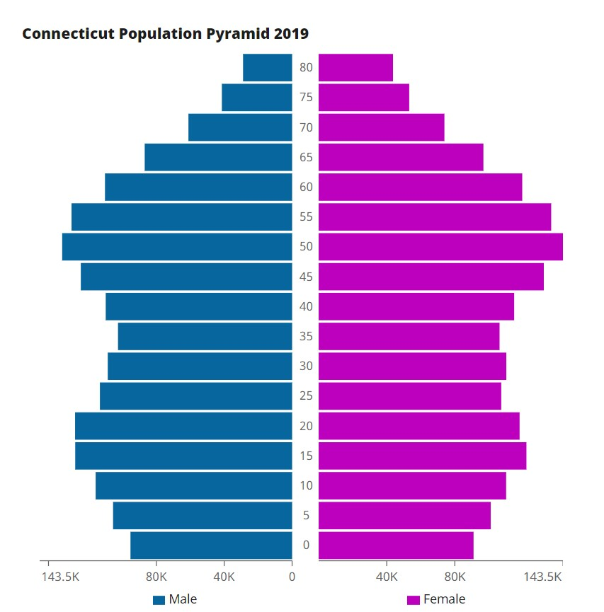

```python
from IPython.display import Image
Image(filename='population pyramid.jpg')
```

In Coonecticut, The population of the age group 45 to 60 is the highest, this may have an impact on the higher number of drug related deaths observed in that age group.

Source for the above image: http://worldpopulationreview.com/states/connecticut-population/

```python
drugs_list = ['Heroin','Cocaine','Fentanyl','Oxycodone','Ethanol',
              'Benzodiazepine','Methadone']
drug_year_tab = df.groupby('YearDate')[drugs_list].count().drop(0)
```

```python
years = drug_year_tab.index.tolist()
heroin = drug_year_tab.Heroin.tolist()
cocain = drug_year_tab.Cocaine.tolist()
fent = drug_year_tab.Fentanyl.tolist()
oxy = drug_year_tab.Oxycodone.tolist()
ethanol = drug_year_tab.Ethanol.tolist()
benzo  = drug_year_tab.Benzodiazepine.tolist()
metha = drug_year_tab.Methadone.tolist()

trace0 = go.Scatter(
    x = years,
    y = heroin,
    name = 'Heroin',
    line = dict(
        color = ('violet'),
        width = 4)
)
trace1 = go.Scatter(
    x = years,
    y = cocain,
    name = 'Cocaine',
    line = dict(
        color = ('indigo'),
        width = 4,)
)
trace2 = go.Scatter(
    x = years,
    y = fent,
    name = 'Fentanyl',
    line = dict(
        color = ('blue'),
        width = 4)
        #dash = 'dash') # dash options include 'dash', 'dot', and 'dashdot'
)
trace3 = go.Scatter(
    x = years,
    y = oxy,
    name = 'Oxycodone',
    line = dict(
        color = ('orange'),
        width = 4)
        #dash = 'dash')
)
trace4 = go.Scatter(
    x = years,
    y = ethanol,
    name = 'Ethanol',
    line = dict(
        color = ('green'),
        width = 4)
        #dash = 'dot')
)
trace5 = go.Scatter(
    x = years,
    y = benzo,
    name = 'Benzodiazepine',
    line = dict(
        color = ('yellow'),
        width = 4,)
       # dash = 'dot')

)
trace6 = go.Scatter(
    x = years,
    y = metha,
    name = 'Methadone',
    line = dict(
        color = ('red'),
        width = 4,)
       # dash = 'dot')
)
data = [trace0, trace1, trace2,trace3, trace4, trace5, trace6]

# Edit the layout
layout = dict(title = 'Type of drug responsible for death for every year',
              xaxis = dict(title = 'Year'),
              yaxis = dict(title = 'Deaths count'),
              )

fig = go.Figure(data=data, layout=layout)
#py.iplot(fig, filename='styled-line')
fig.show()
```

[interactive chart not shown]

#### • Heroin had been responsible for maximum deaths due to drug over dose but since 2015 the deaths caused due to Fentanyl Consumption have increased. Fentanyl overdose has caused maximum number of deaths in 2017 and 2108.

#### • Heroin is sold illegally, so there is no control over the quality or strength of the drug.Various projects are underway throughout the state, which are designed to strengthenthe state’s capacity for overdose surveillance and the identification of “hot spots”.TheConnecticut Poison Control Center has piloted a syndromic surveillance system whichrequires Emergency Medical Services (EMS). We can see above the impact of policies there has been a reduction in deaths due to heroin but people circumvent the laws and Fentanyl appears to be the replacement of the former.

```python
drugs_list = ['Heroin','Cocaine','Fentanyl','Oxycodone','Ethanol',
              'Benzodiazepine','Methadone']
```

```python
dfgd=df.groupby(['Age_Group'])[drugs_list].count()
dfgd
```

| Age_Group | Heroin | Cocaine | Fentanyl | Oxycodone | Ethanol | Benzodiazepine | Methadone |
| --- | --- | --- | --- | --- | --- | --- | --- |
| 0 to 21 | 49 | 14 | 40 | 7 | 11 | 27 | 3 |
| 21 to 32 years | 674 | 286 | 566 | 85 | 215 | 249 | 68 |
| 33 to 45 years | 774 | 478 | 743 | 147 | 363 | 397 | 141 |
| 46 to 60 years | 856 | 620 | 712 | 302 | 557 | 534 | 215 |
| 60+ | 172 | 116 | 164 | 64 | 96 | 131 | 45 |

```python
fig = go.Figure(data=[
    go.Bar(name='Heroin', x=dfgd.index, y=dfgd.Heroin),
    go.Bar(name='Fentanyl', x=dfgd.index, y=dfgd.Fentanyl),
    go.Bar(name='Cocaine', x=dfgd.index, y=dfgd.Cocaine),
    go.Bar(name='Benzodiazepine', x = dfgd.index, y=dfgd.Benzodiazepine),
    go.Bar(name='Ethanol', x = dfgd.index, y=dfgd. Ethanol),
    go.Bar(name='Oxycodone', x = dfgd.index, y=dfgd.Oxycodone),
    go.Bar(name='Methadone', x = dfgd.index, y=dfgd.Methadone)
],
layout = dict(title = 'Type of drug consumed by different age groups',
              xaxis = dict(title = 'Age Group'),
              yaxis = dict(title = 'Deaths count'),
              ))
# Change the bar mode
fig.update_layout(barmode='group')
fig.show()
```

[interactive chart not shown]

#### • Heroin overodse killed maximum number of people who were in the age group 45-60 years .

#### • Heroin is the most consumed drug followed by Fentanyl across all age groups.

```python
#df.head()
```

```python
mapbox_access_token = 'pk.eyJ1IjoicHJhY2hpdHAiLCJhIjoiY2sycGJ4YmxqMDJxMTNubXcxbWQ3bnE4cCJ9.rrsi4NcKGXS3x0yOUdsNnQ'
```

```python
for index, row in df.iterrows():
    df.loc[index, 'DeathCity_Coordinates']=row['DeathCity_Coordinates'][1:-1]
```

```python
new = df["DeathCity_Coordinates"].str.split(",", n = 1, expand = True)
new[0].astype(float)
new[1].astype(float)
new=new.rename(columns={0: "DeathCity_Lat", 1: "DeathCity_Lon"})
df = df.merge(new, left_index=True, right_index=True)
df.drop(columns=['DeathCity_Coordinates'])
```

[output not shown]

5089 rows × 46 columns

```python
grouped_df =df.groupby(['DeathCity_Lat', 'DeathCity_Lon','DeathCityGeo']).size()
df_count = grouped_df.to_frame()
df_count = df_count.reset_index(level=['DeathCity_Lat',"DeathCity_Lon",'DeathCityGeo'])
df_count = df_count.rename(columns={0: "Count"})
df_count.head()
```

|  | DeathCity_Lat | DeathCity_Lon | DeathCityGeo | Count |
| --- | --- | --- | --- | --- |
| 0 | 41.026526 | -73.628549 | GREENWICH, CT | 22 |
| 1 | 41.037899 | -73.599776 | COS COB, CT | 3 |
| 2 | 41.051924 | -73.539475 | STAMFORD, CT | 76 |
| 3 | 41.077925 | -73.216497 | 06340, CT | 1 |
| 4 | 41.080002 | -73.467371 | DARIEN, CT | 3 |

```python
df_count.head()
df_count['DeathCity_Lat']=pd.to_numeric(df_count['DeathCity_Lat'])
df_count['DeathCity_Lon']=pd.to_numeric(df_count['DeathCity_Lon'])
#df_count.dtypes
```

```python
import plotly.express as px
px.set_mapbox_access_token(mapbox_access_token)

fig = px.scatter_mapbox(df_count, lat="DeathCity_Lat", lon="DeathCity_Lon", color="Count",hover_name="DeathCityGeo", size="Count",
                 color_continuous_scale='Viridis', size_max=40, zoom=8)
fig.update_layout(
    title={
        'text': "Drug Related Deaths ",
        'y':0.9,
        'x':0.5,
        'xanchor': 'center',
        'yanchor': 'top'})
fig.show()
```

[interactive chart not shown]

#### • Hartford Police and public health officials are facing challenges and working hard to determine what’s fueling the fentanyl epidemic in the city.

#### • Since its the capital of the State a massive campaign can be launched to address the issue through an effective use of media and technology.

### Question: Which gender had high ratio for drug intoxication deaths?

```python
dfg = df.groupby(['Age_Group','Sex']) ['Sex'].count()
genderdf = dfg.unstack()
genderdf = genderdf.reset_index()
genderdf = genderdf.drop(['Unknown'], axis=1)
genderdf
```

| Sex | Age_Group | Female | Male |
| --- | --- | --- | --- |
| 0 | 0 to 21 | 30.0 | 61.0 |
| 1 | 21 to 32 years | 296.0 | 868.0 |
| 2 | 33 to 45 years | 340.0 | 1151.0 |
| 3 | 46 to 60 years | 547.0 | 1375.0 |
| 4 | 60+ | 107.0 | 313.0 |

```python
fig1 = go.Figure(data=[
    go.Bar(name='Male', x=genderdf.Age_Group, y=genderdf.Male, marker_color='dodgerblue'),
    go.Bar(name='Female', x=genderdf.Age_Group, y=genderdf.Female, marker_color='lightblue')],

layout = dict(title = 'Number of deaths due to drug consumption on the basis of gender ',
              xaxis = dict(title = 'Age Group'),
              yaxis = dict(title = 'Deaths count')
              )
)
# Change the bar mode
fig1.update_layout(barmode='stack')
fig1.show()
```

[interactive chart not shown]

#### • The number of deaths for males in range of 33 to 60 years is maximum.

#### • We can see that the death count is more for males with a maximum of 1375 deaths for age between 46 and 60 years.We also can see that the second highest number of deaths is for age 33 to 45 years.

```python
order = ['Male','Female','Unknown']
dfg1 = df.groupby(['Sex'])[drugs_list].count()
dfg2 = dfg1.loc[order]
dfg2
dfg2
```

| Sex | Heroin | Cocaine | Fentanyl | Oxycodone | Ethanol | Benzodiazepine | Methadone |
| --- | --- | --- | --- | --- | --- | --- | --- |
| Male | 1987 | 1135 | 1759 | 401 | 969 | 877 | 313 |
| Female | 538 | 379 | 466 | 203 | 273 | 461 | 158 |
| Unknown | 0 | 0 | 0 | 1 | 0 | 0 | 1 |

```python
fig2 = go.Figure(data=[
    go.Bar(name='Heroin', y = dfg2.index, x = dfg2.Heroin, orientation = 'h'),
    go.Bar(name='Fentanyl', y = dfg2.index, x = dfg2.Fentanyl, orientation = 'h'),
    go.Bar(name='Cocaine', y = dfg2.index, x = dfg2.Cocaine, orientation = 'h'),
    go.Bar(name='Benzodiazepine', y = dfg2.index, x = dfg2.Benzodiazepine, orientation = 'h'),
    go.Bar(name='Ethanol', y = dfg2.index, x = dfg2.Ethanol,orientation = 'h'),
    go.Bar(name='Oxycodone', y = dfg2.index, x = dfg2.Oxycodone, orientation = 'h'),
    go.Bar(name='Methadone', y = dfg2.index, x = dfg2.Methadone, orientation = 'h')
],
layout = dict(title = 'Type of drug consumed by the gender',
              xaxis = dict(title = 'Deaths count'),
              yaxis = dict(title = 'Gender'),
              ))
# Change the bar mode
fig2.update_layout(barmode='group')
fig2.show()
```

[interactive chart not shown]

#### • The deaths for males consuming Heroine and Fentanyl is highest with a count of 1987 and 1759 respectively.